# Exercises of Models Course

Quantide Srl

July 6, 2016

## ANOVA

### Exercise 1

A society that produces ballpoint pens uses a multi-head machine for the production of caps for pens. The productor wants to determine if there are differences on the means of the different heads.

```r
data(pencap)
head(pencap)
```

```
## Source: local data frame [6 x 2]
##
##   Cavity  Width
##    (int)  (dbl)
## 1      1  9.920
## 2      1 10.006
## 3      1  9.936
## 4      1  9.963
## 5      1 10.004
## 6      1 10.004
```

1. Let us compute descriptive statistics and generate the BW plot of `Width` for each head (`Cavity`).

```r
# Descriptive Statistics
summary_stat <- pencap %>% group_by(Cavity) %>%
  summarise(n=n(),
  min = min(Width),
  first_qu = quantile(Width, 0.25),
  median = median(Width),
  mean = mean(Width),
  third_qu = quantile(Width, 0.75),
  max = max(Width),
  sd = sd(Width))

print(summary_stat)
```

```
## Source: local data frame [16 x 9]
##
##    Cavity     n   min first_qu  median     mean third_qu    max         sd
##     (int) (int) (dbl)    (dbl)   (dbl)    (dbl)    (dbl)  (dbl)      (dbl)
## 1       1    20 9.920  9.95375  9.9880  9.98120 10.00450 10.038 0.03301132
## 2       2    20 9.941  9.98650 10.0135 10.01535 10.03850 10.088 0.04212297
## 3       3    20 9.967 10.02250 10.0310 10.03010 10.04350 10.076 0.02615722
## 4       4    20 9.904  9.97150  9.9950  9.98635 10.00550 10.038 0.03252897
## 5       5    20 9.967 10.01250 10.0285 10.02935 10.04425 10.115 0.03480665
## 6       6    20 9.957  9.98750 10.0075 10.00770 10.03525 10.052 0.02757974
## 7       7    20 9.901  9.94500  9.9730  9.96675  9.98300 10.050 0.03829371
## 8       8    20 9.983 10.00250 10.0320 10.02805 10.04700 10.076 0.02804972
## 9       9    20 9.936  9.96200  9.9785  9.97940  9.99350 10.044 0.02710098
## 10     10    20 9.936  9.98550  9.9990  9.99920 10.01825 10.062 0.03168696
## 11     11    20 9.950  9.99550 10.0145 10.01380 10.04325 10.055 0.03101035
## 12     12    20 9.862  9.96500  9.9920  9.98085 10.00550 10.025 0.03778788
## 13     13    20 9.931  9.97175  9.9860  9.99225 10.00925 10.089 0.03918361
## 14     14    20 9.933  9.99150 10.0150 10.00880 10.02775 10.070 0.03649023
## 15     15    20 9.911  9.94550  9.9685  9.97130  9.98825 10.038 0.03616061
## 16     16    20 9.970 10.01700 10.0275 10.02605 10.04600 10.079 0.03168176
```

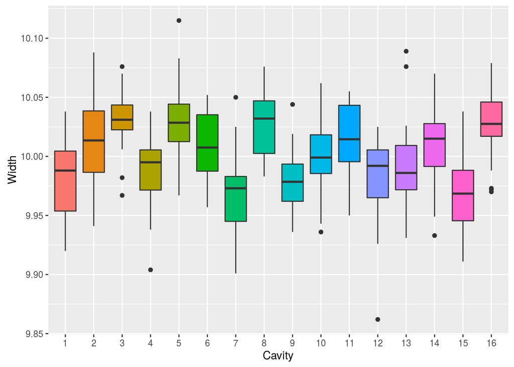

```r
# BW Plot
pencap <- pencap %>% mutate(Cavity=factor(Cavity))
ggp <- ggplot(data=pencap, mapping = aes(x=Cavity, y=Width, fill=Cavity)) +
  geom_boxplot(show.legend = FALSE)
print(ggp)
```

2. Let us fit a model to check if there are differences between the means of the different groups. Let us use `options(contrasts = c("contr.treatment", "contr.poly"))` contrasts type and comment the results.

```r
options(contrasts = c("contr.treatment", "contr.poly"))
fm <- aov(Width~Cavity, data = pencap)
summary(fm)
```

```
##              Df Sum Sq  Mean Sq F value   Pr(>F)
## Cavity       15 0.1420 0.009466    8.35 5.92e-16 ***
## Residuals   304 0.3446 0.001134
## ---
## Signif. codes:  0 '***' 0.001 '**' 0.01 '*' 0.05 '.' 0.1 ' ' 1
```

```r
# aov()’s predefined output gives a global p-value of 5.92e-16 on Cavity effect.
summary.lm(fm)
```

```
##
## Call:
## aov(formula = Width ~ Cavity, data = pencap)
##
## Residuals:
##       Min        1Q    Median        3Q       Max
## -0.118850 -0.021137  0.001775  0.020050  0.096750
##
## Coefficients:
##              Estimate Std. Error  t value Pr(>|t|)
## (Intercept)  9.981200   0.007529 1325.752  < 2e-16 ***
## Cavity2      0.034150   0.010647    3.207  0.00148 **
## Cavity3      0.048900   0.010647    4.593 6.41e-06 ***
## Cavity4      0.005150   0.010647    0.484  0.62895
## Cavity5      0.048150   0.010647    4.522 8.78e-06 ***
## Cavity6      0.026500   0.010647    2.489  0.01335 *
## Cavity7     -0.014450   0.010647   -1.357  0.17574
## Cavity8      0.046850   0.010647    4.400 1.50e-05 ***
## Cavity9     -0.001800   0.010647   -0.169  0.86586
## Cavity10     0.018000   0.010647    1.691  0.09194 .
## Cavity11     0.032600   0.010647    3.062  0.00240 **
## Cavity12    -0.000350   0.010647   -0.033  0.97380
## Cavity13     0.011050   0.010647    1.038  0.30017
## Cavity14     0.027600   0.010647    2.592  0.01000 **
## Cavity15    -0.009900   0.010647   -0.930  0.35320
## Cavity16     0.044850   0.010647    4.212 3.33e-05 ***
## ---
## Signif. codes:  0 '***' 0.001 '**' 0.01 '*' 0.05 '.' 0.1 ' ' 1
##
## Residual standard error: 0.03367 on 304 degrees of freedom
## Multiple R-squared:  0.2918, Adjusted R-squared:  0.2568
## F-statistic:  8.35 on 15 and 304 DF,  p-value: 5.922e-16
```

```r
# Results interpretation: Cavity1 mean appears significantly different from 0 (B0 = 9.981200, p = 2e-16), Cavity2 mean seems significantly different from Cavity1 (0.034150 greater, p-value=0.00148), ...
```

3. Let us check model residuals.

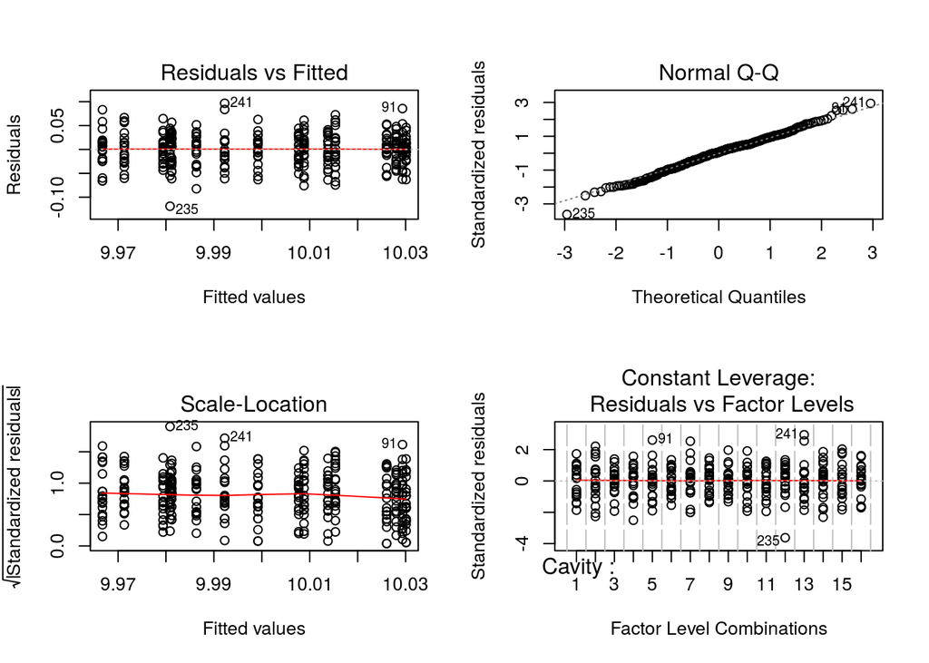

```r
op <- par(mfrow = c(2,2))
plot(fm)
```

```r
par(op)
# The residual plots confirm that normality and homoscedasticity assumptions are met, and no outliers appear.
```

### Exercise 2

A chemist conducts an experiment to evaluate the efficacy of a solvent to dissolve stains of nail varnish from fabrics. He uses two types of solvent and three types of varnish. The experiment consists of immersing 5 stained fabrics by a certain type of varnish into a bowl with a solvent and of measuring the time (in minutes) necessary to dissolve the stain.

```r
data(varnish)
head(varnish)
```

```
## Source: local data frame [6 x 3]
##
##   Solvent Varnish  Time
##     (int)   (int) (dbl)
## 1       2       3 32.50
## 2       1       3 30.20
## 3       1       3 27.25
## 4       2       3 24.25
## 5       2       2 34.42
## 6       2       2 26.00
```

1. Let us compute descriptive statistics and generate the BW plot of `Time` for each level of `Solvent` and `Varnish`. Let us draw also a BW plot for each combination of `Solvent` and `Varnish` factor levels.

```r
# Descriptive Statistics of Time for each level of Solvent
summary_stat <- varnish %>% group_by(Solvent) %>%
  summarise(n=n(),
  min = min(Time),
  first_qu = quantile(Time, 0.25),
  median = median(Time),
  mean = mean(Time),
  third_qu = quantile(Time, 0.75),
  max = max(Time),
  sd = sd(Time))

print(summary_stat)
```

```
## Source: local data frame [2 x 9]
##
##   Solvent     n   min first_qu median     mean third_qu   max      sd
##     (int) (int) (dbl)    (dbl)  (dbl)    (dbl)    (dbl) (dbl)   (dbl)
## 1       1    15 21.50   23.625  25.83 25.99067    28.25 30.20 2.91969
## 2       2    15 24.25   28.625  29.50 29.59467    31.50 34.42 2.87933
```

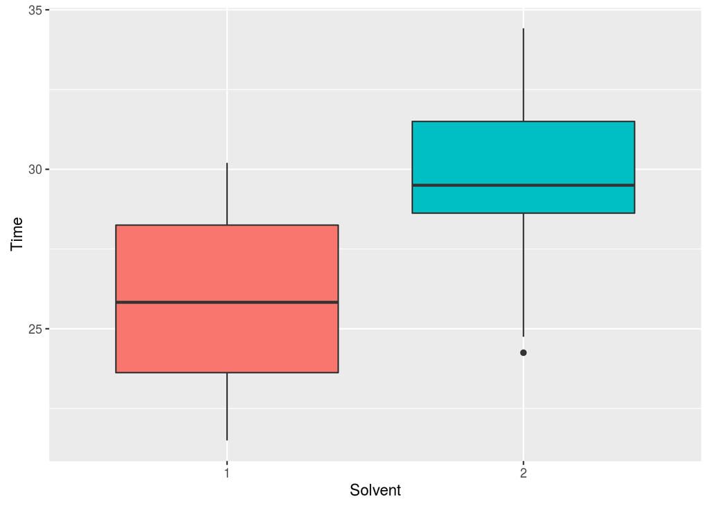

```r
# BW Plot of Time for each level of Solvent
varnish <- varnish %>% mutate(Solvent=factor(Solvent))
ggp <- ggplot(data=varnish, mapping = aes(x=Solvent, y=Time, fill=Solvent)) +
  geom_boxplot(show.legend = FALSE)
print(ggp)
```

```r
# Descriptive Statistics of Time for each level of Varnish
summary_stat <- varnish %>% group_by(Varnish) %>%
  summarise(n=n(),
  min = min(Time),
  first_qu = quantile(Time, 0.25),
  median = median(Time),
  mean = mean(Time),
  third_qu = quantile(Time, 0.75),
  max = max(Time),
  sd = sd(Time))

print(summary_stat)
```

```
## Source: local data frame [3 x 9]
##
##   Varnish     n   min first_qu median   mean third_qu   max       sd
##     (int) (int) (dbl)    (dbl)  (dbl)  (dbl)    (dbl) (dbl)    (dbl)
## 1       1    10 22.08  27.8100 28.960 28.624  30.7500 32.08 3.000986
## 2       2    10 21.50  24.8125 25.585 26.734  28.8150 34.42 3.946560
## 3       3    10 22.75  25.1875 29.125 28.020  30.0875 32.50 3.213876
```

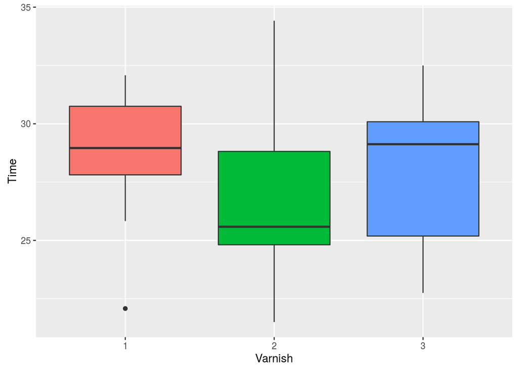

```r
# BW Plot of Time for each level of Solvent
varnish <- varnish %>% mutate(Varnish=factor(Varnish))
ggp <- ggplot(data=varnish, mapping = aes(x=Varnish, y=Time, fill=Varnish)) +
  geom_boxplot(show.legend = FALSE)
print(ggp)
```

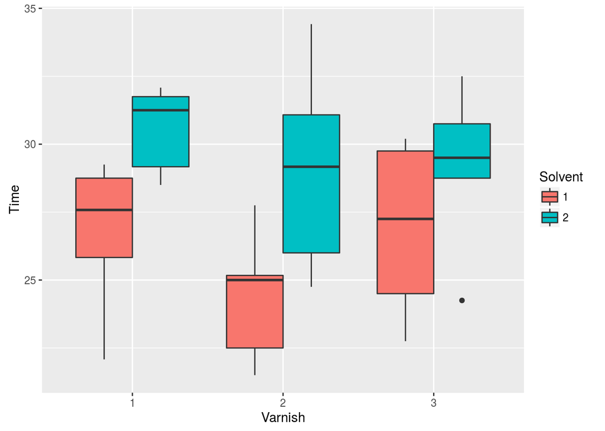

```r
# BW plot for each combination of Solvent and Varnish factor levels
ggp <- ggplot(data = varnish, mapping = aes(x=Varnish, y=Time, fill=Solvent)) +
  geom_boxplot()

print(ggp)
```

2. Let us evaluate also if there are differences in solvent types in respect of the varnish types that produced the stain (Considerer also the interaction in model formulation).

```r
fm <- aov(Time ~ Varnish * Solvent, data = varnish)
summary(fm)
```

```
##                 Df Sum Sq Mean Sq F value  Pr(>F)
## Varnish          2  18.64    9.32   1.069 0.35899
## Solvent          1  97.42   97.42  11.181 0.00271 **
## Varnish:Solvent  2   7.67    3.84   0.440 0.64893
## Residuals       24 209.10    8.71
## ---
## Signif. codes:  0 '***' 0.001 '**' 0.01 '*' 0.05 '.' 0.1 ' ' 1
```

```r
# Actually, only main effects Solvent seems to influence the time necessary to dissolve the stain.  Interaction seem not significant: we can start to drop it.
```

3. Let us improve the model, dropping non significant terms (one by one).

```r
# Drop the interaction from model formulation Varnish:Solvent
fm1 <- update(fm, . ~ . -Varnish:Solvent)
summary(fm1)
```

```
##             Df Sum Sq Mean Sq F value  Pr(>F)
## Varnish      2  18.64    9.32   1.118 0.34228
## Solvent      1  97.42   97.42  11.684 0.00209 **
## Residuals   26 216.78    8.34
## ---
## Signif. codes:  0 '***' 0.001 '**' 0.01 '*' 0.05 '.' 0.1 ' ' 1
```

```r
# Drop Varnish effect from model formulation
fm2 <- update(fm1, . ~ . -Varnish)
summary(fm2)
```

```
##             Df Sum Sq Mean Sq F value  Pr(>F)
## Solvent      1  97.42   97.42   11.59 0.00202 **
## Residuals   28 235.41    8.41
## ---
## Signif. codes:  0 '***' 0.001 '**' 0.01 '*' 0.05 '.' 0.1 ' ' 1
```

4. Let us check if the removed effect/s are not significant (models comparison).

```r
anova(fm, fm2)
```

```
## Analysis of Variance Table
##
## Model 1: Time ~ Varnish * Solvent
## Model 2: Time ~ Solvent
##   Res.Df    RSS Df Sum of Sq      F Pr(>F)
## 1     24 209.10
## 2     28 235.41 -4   -26.308 0.7549 0.5647
```

```r
# The removed effects are not significant.
```

5. Let us check (final) models residuals.

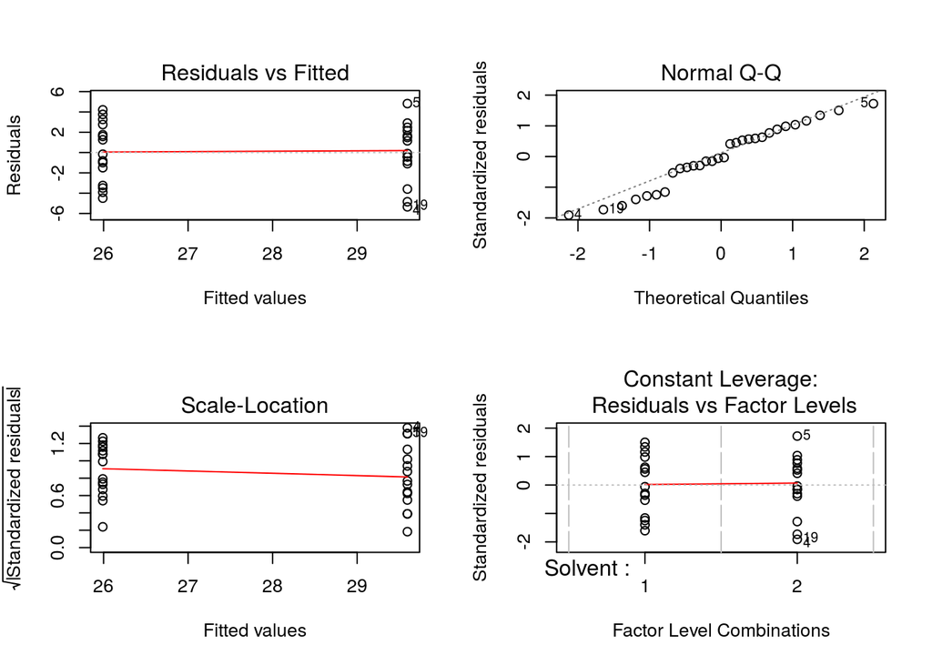

```r
op <- par(mfrow = c(2,2))
plot(fm2)
```

```r
par(op)
# The residual plots confirm that normality and homoscedasticity assumptions are met, and no outliers appear.
```

## Linear models

### Exercise 1

The number of impurities (lumps) present in the containers of paint depends on the rate of agitation applied to the container. A researcher wants to determine the relation between the rate of agitation and the number of lumps, so he conducts an experiment. He applies different rates of agitation (`Stirrate`) to 12 containers of paint and he counts the number of impurities (lumps) present in the containers of paint (`Impurity`).

```r
data(paint)
head(paint)
```

```
## Source: local data frame [6 x 2]
##
##   Stirrate Impurity
##      (int)    (dbl)
## 1       20      8.4
## 2       38     16.5
## 3       36     16.4
## 4       40     18.9
## 5       42     18.5
## 6       26     10.4
```

1. Let us compute the main descriptive statistics and generate the BW plot of `Impurity`. Let us compute also the correlation and the correlation plot between `Impurity` and `Stirrate`.

```r
# Descriptive Statistics
summary_stat <- paint %>% summarise(n=n(),
  min = min(Impurity),
  first_qu = quantile(Impurity, 0.25),
  median = median(Impurity),
  mean = mean(Impurity),
  third_qu = quantile(Impurity, 0.75),
  max = max(Impurity),
  sd = sd(Impurity))

print(summary_stat)
```

```
## Source: local data frame [1 x 8]
##
##       n   min first_qu median     mean third_qu   max       sd
##   (int) (dbl)    (dbl)  (dbl)    (dbl)    (dbl) (dbl)    (dbl)
## 1    12   8.4    11.45     14 13.86667   16.425  18.9 3.407567
```

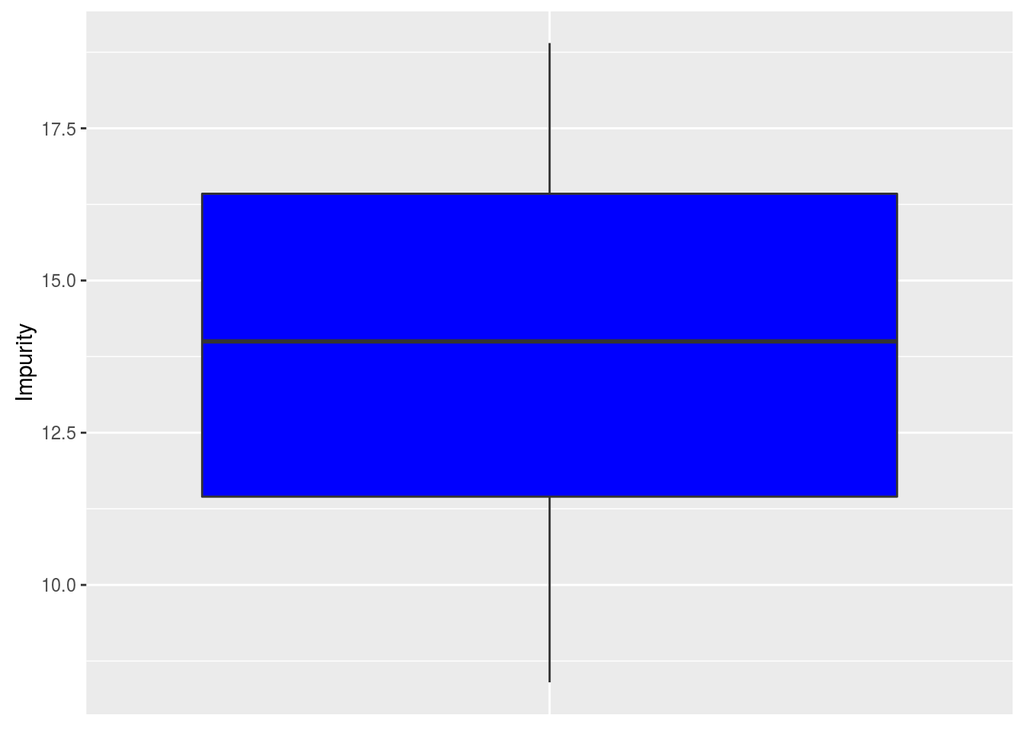

```r
# Boxplot
ggp <- ggplot(data = paint, mapping = aes(x="0", y=Impurity)) +
  geom_boxplot(fill="blue") + theme(axis.text.x=element_blank(), axis.title.x = element_blank(),
    axis.ticks.x=element_blank())
print(ggp)
```

```r
# Correlation
paint %>% summarise(cor=cor(Stirrate, Impurity))
```

```
## Source: local data frame [1 x 1]
##
##         cor
##       (dbl)
## 1 0.9663498
```

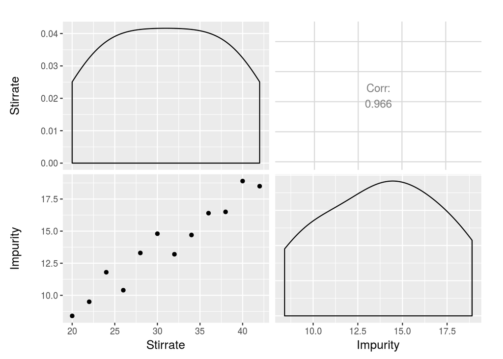

```r
pl <- ggpairs(data = paint)
print(pl)
```

2. Let us graphically represent the relation between these variables (add regression line to the graph).

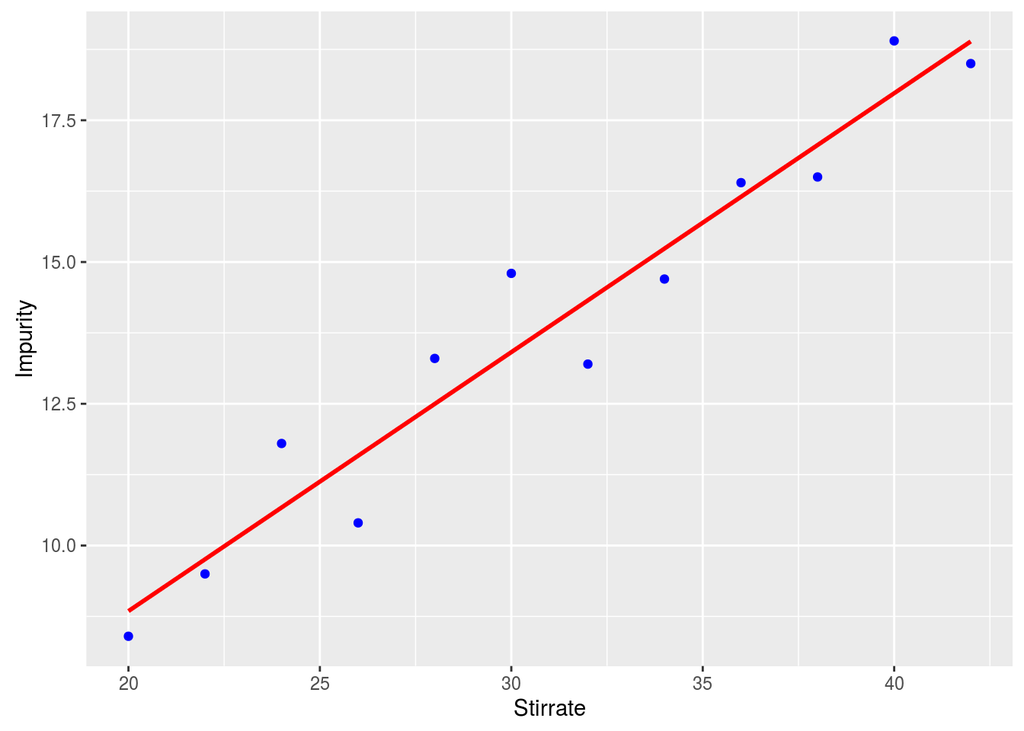

```r
pl <- ggplot(data = paint, mapping = aes(x = Stirrate, y=Impurity)) +
  geom_point(color="blue") +
  geom_smooth(method = "lm", colour="red", se = FALSE)

print(pl)
```

```r
# A simple straight linear regression is a good choice to describe the relation
```

3. Let us compute a simple linear regression between `Impurity` and `Stirrate`. Does `Stirrate` influence `Impurity`? How?

```r
# Fit the linear model
fm <- lm(formula = Impurity ~ Stirrate, data = paint)
summary(fm)
```

```
##
## Call:
## lm(formula = Impurity ~ Stirrate, data = paint)
##
## Residuals:
##     Min      1Q  Median      3Q     Max
## -1.1834 -0.5432 -0.3233  0.8333  1.3900
##
## Coefficients:
##             Estimate Std. Error t value Pr(>|t|)
## (Intercept) -0.28928    1.22079  -0.237    0.817
## Stirrate     0.45664    0.03844  11.880 3.21e-07 ***
## ---
## Signif. codes:  0 '***' 0.001 '**' 0.01 '*' 0.05 '.' 0.1 ' ' 1
##
## Residual standard error: 0.9193 on 10 degrees of freedom
## Multiple R-squared:  0.9338, Adjusted R-squared:  0.9272
## F-statistic: 141.1 on 1 and 10 DF,  p-value: 3.211e-07
```

```r
# The relation that "links" the revolution rate seems to be well described by a simple linear regression, at least for the considered interval of Stirrate. It appears that if we increase Stirrate by one unit, impurities increase by 0.46 on average, and this growth is significant. The p-value for the significativity of the coefficient of Stirrate is extremely low. This fact confirms the "non random" existing relation between the two variables. The p-value of the intercept estimate is 0.817. This would indicate an intercept potentially equal to 0. Keeping the intercept value equal to the estimate, with value of Stirrate=0, the mean number of imputities would be negative: the results of the regression couldn’t be "extended" too outside experimental field. R^2 value is equal to 0.9338; this fact confirms that the model explais well the observed data.
```

4. Let us check (final) models residuals.

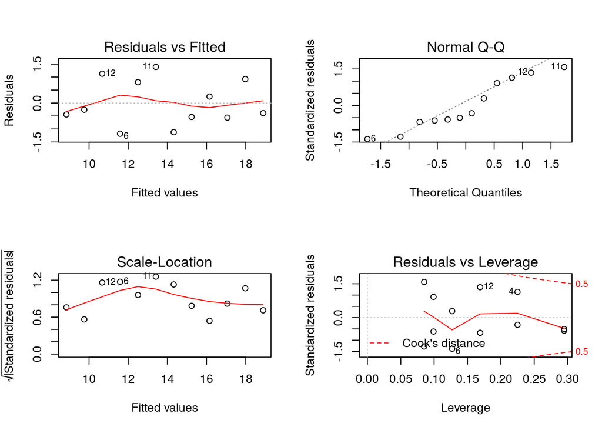

```r
# Residuals analysis
op <- par(mfrow = c(2,2))
plot(fm)
```

```r
par(op)
# Plots do not evidence particular problems.
```

### Exercise 2

A pressure switch has a membrane whose thickness (in mm) influences the pressure required to trigger the switch itself. The aim is to determine the thickness of the membrane for which the switch “trig” with a pressure equal to 165 ± 15 KPa. 25 switches with different thickness (`DThickness`) of the membrane was analysed, measuring the the pressure at which each switch opens (KPa) (`SetPoint`).

```r
data(switcht)
head(switcht)
```

```
## Source: local data frame [6 x 2]
##
##   DThickness SetPoint
##        (dbl)    (dbl)
## 1        0.9  223.523
## 2        0.6  157.131
## 3        0.5  149.307
## 4        0.8  200.146
## 5        0.8  199.974
## 6        0.7  166.919
```

1. Let us compute the descriptive statistics and generate the BW-plot of the variable `SetPoint`.

```r
# Descriptive Statistics
summary_stat <- switcht %>% summarise(n=n(),
  min = min(SetPoint),
  first_qu = quantile(SetPoint, 0.25),
  median = median(SetPoint),
  mean = mean(SetPoint),
  third_qu = quantile(SetPoint, 0.75),
  max = max(SetPoint),
  sd = sd(SetPoint))

print(summary_stat)
```

```
## Source: local data frame [1 x 8]
##
##       n     min first_qu  median     mean third_qu     max       sd
##   (int)   (dbl)    (dbl)   (dbl)    (dbl)    (dbl)   (dbl)    (dbl)
## 1    25 144.674  157.353 174.796 181.0909  199.974 231.725 27.70451
```

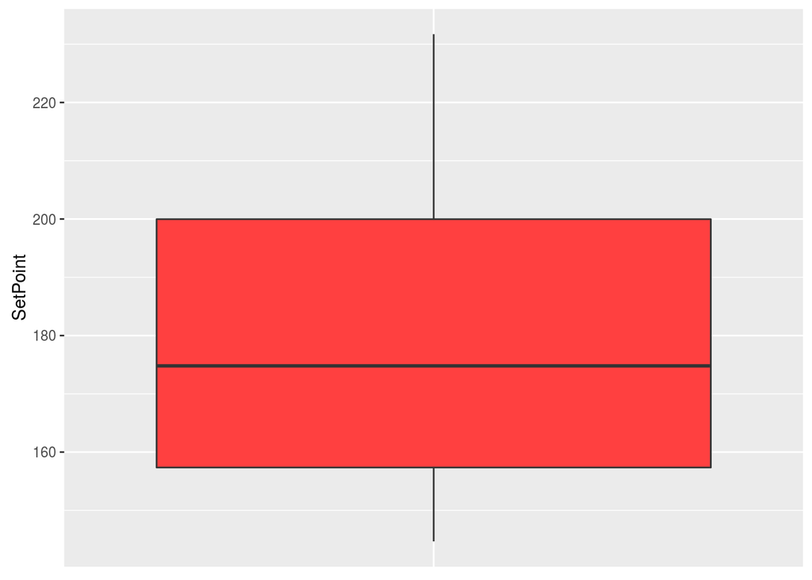

```r
# Boxplot
ggp <- ggplot(data = switcht, mapping = aes(x="0", y=SetPoint)) +
  geom_boxplot(fill = "brown1") + theme(axis.text.x=element_blank(), axis.title.x = element_blank(),
    axis.ticks.x=element_blank())

print(ggp)
```

2. Let us graphically represent the relation between `DThickness` and `SetPoint`(add regression line to the graph).

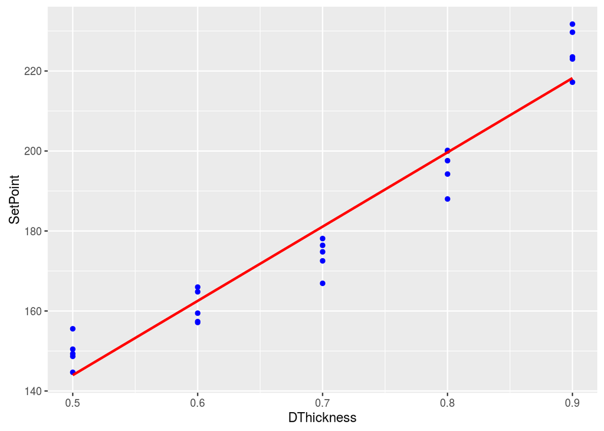

```r
pl <- ggplot(data = switcht, mapping = aes(x = DThickness, y=SetPoint)) +
  geom_point(color="blue") +
  geom_smooth(method = "lm", colour="red", se = FALSE)

print(pl)
```

3. Let us compute a linear regression between `DThickness` and `SetPoint` and check the residuals of the fitted model. Does `DThickness` influences `SetPoint`? Is the model correct?

```r
# Fit the linear model
fm1 <- lm(formula = SetPoint ~ DThickness, data = switcht)
summary(fm1)
```

```
##
## Call:
## lm(formula = SetPoint ~ DThickness, data = switcht)
##
## Residuals:
##      Min       1Q   Median       3Q      Max
## -14.1719  -5.1742   0.3194   4.7807  13.5067
##
## Coefficients:
##             Estimate Std. Error t value Pr(>|t|)
## (Intercept)   51.145      7.266   7.039 3.58e-07 ***
## DThickness   185.637     10.174  18.246 3.54e-15 ***
## ---
## Signif. codes:  0 '***' 0.001 '**' 0.01 '*' 0.05 '.' 0.1 ' ' 1
##
## Residual standard error: 7.194 on 23 degrees of freedom
## Multiple R-squared:  0.9354, Adjusted R-squared:  0.9326
## F-statistic: 332.9 on 1 and 23 DF,  p-value: 3.542e-15
```

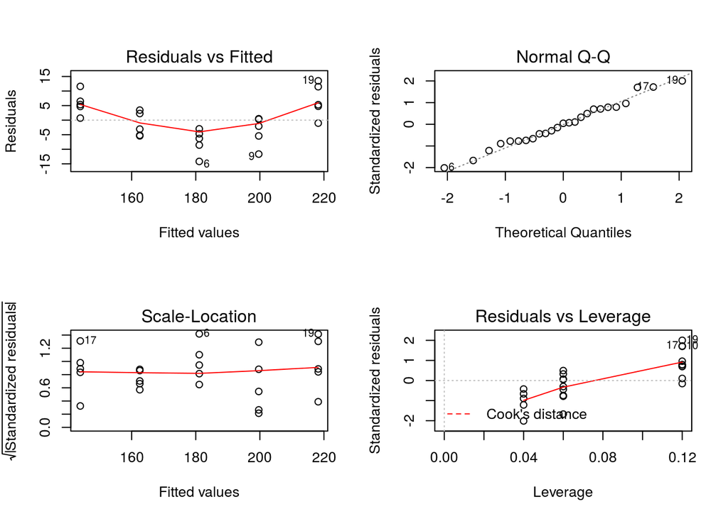

```r
# The relation that "links" the thickness of diaphragm with the pressure for which the switch trigs seems well described by a simple linear regression, at least in the considered interval. The p-value for the significativity of the coefficient of DThickness is extremely low. This fact confirms the "non random" existing relation between the two variables. The p-value of the estimate of the intercept is very low. The intercept is significative. R^2 value is 0.9354. This fact confirms that the model explains well the observed data.

# Residuals analysis
op <- par(mfrow = c(2,2))
plot(fm1)
```

```r
par(op)

# The graphic of the residual values in respect of the estimated values shows a curvilinear trend. This fact implies that the model could be improved, for example with a quadratic model.
```

4. Let us improve the model and compare it with the previous model, if necessary.

```r
# Improve the model
fm2 <- update(fm1,.~. + I(DThickness^2))
summary(fm2)
```

```
##
## Call:
## lm(formula = SetPoint ~ DThickness + I(DThickness^2), data = switcht)
##
## Residuals:
##     Min      1Q  Median      3Q     Max
## -8.4280 -2.1128  0.0533  3.5390  7.0676
##
## Coefficients:
##                 Estimate Std. Error t value Pr(>|t|)
## (Intercept)       202.47      26.24   7.717 1.07e-07 ***
## DThickness       -265.10      77.19  -3.434  0.00237 **
## I(DThickness^2)   321.96      54.94   5.860 6.76e-06 ***
## ---
## Signif. codes:  0 '***' 0.001 '**' 0.01 '*' 0.05 '.' 0.1 ' ' 1
##
## Residual standard error: 4.597 on 22 degrees of freedom
## Multiple R-squared:  0.9748, Adjusted R-squared:  0.9725
## F-statistic: 424.9 on 2 and 22 DF,  p-value: < 2.2e-16
```

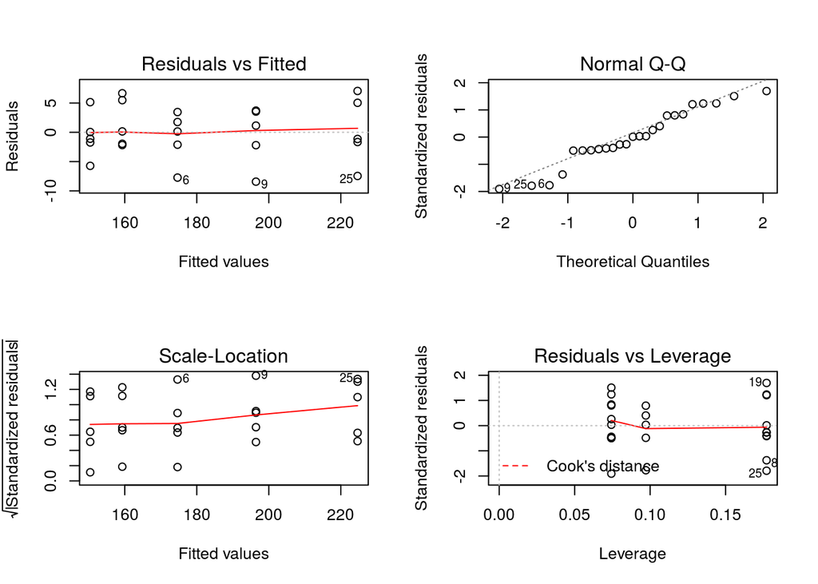

```r
# The p-value of the quadratic term is significant, so the quadratic term explains a great quantity of variation in the response in respect of that explained by the linear model. R^2 value is 0.9748, This value is certainly better than the same value of the simple linear model.

# Residuals analysis
op <- par(mfrow = c(2,2))
plot(fm2)
```

```r
par(op)

# The graphic of the estimated values vs residuals doesn’t show any systematic trend of the residuals and the variance seems to be the same for each estimated value. The residuals are quite well aligned on the line representing the quantile of the normal distribution: It is reasonable to assume that they are then normally distributed.

# Comparison with the previous model
anova(fm1, fm2)
```

```
## Analysis of Variance Table
##
## Model 1: SetPoint ~ DThickness
## Model 2: SetPoint ~ DThickness + I(DThickness^2)
##   Res.Df     RSS Df Sum of Sq     F    Pr(>F)
## 1     23 1190.45
## 2     22  464.86  1    725.59 34.34 6.761e-06 ***
## ---
## Signif. codes:  0 '***' 0.001 '**' 0.01 '*' 0.05 '.' 0.1 ' ' 1
```

```r
# This analysis confirms that the contribution of quadratic term is significant.
```

5. Let us produce the graph of predicted values from the best model estimated.

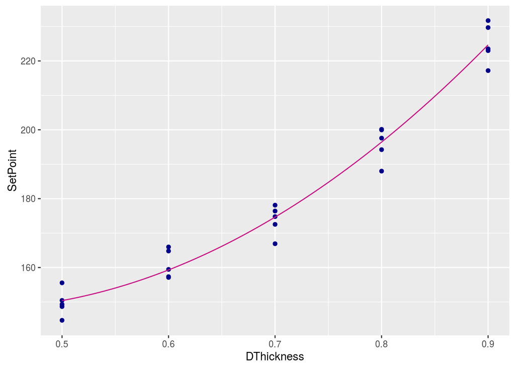

```r
# Plot of predition from quadratic model
newdata <- data.frame(DThickness = seq(min(switcht$DThickness),
  max(max(switcht$DThickness)), length = 100))
newdata$predict <- predict(fm2, newdata = newdata)

ggp <- ggplot(data=switcht, mapping = aes(x=DThickness, y=SetPoint)) +
  geom_point(colour="darkblue") +
  geom_line(data=newdata, mapping=aes(x=DThickness, y=predict), colour="mediumvioletred")

print(ggp)
```

### Exercise 3

The engeneers want to reduce the knocking of the engines. Before doing this, they have to identify which variables influence this phenomenon. Data are randomly collected from 13 engines and contains the following variables:

- `Spark`: indicates the time of advance of the spark plug ignition;
- `AFR`: indicates the air fuel ratio (Air Fuel Ratio);
- `Intake`: indicates the inlet temperature;
- `Exhaust`: indicates the exhaust temperature;
- `Knock`: indicates the knocking of the engine.

```r
data(knock)
head(knock)
```

```
## Source: local data frame [6 x 5]
##
##   Spark   AFR Intake Exhaust Knock
##   (dbl) (dbl)  (int)   (int) (dbl)
## 1  14.5  13.9     31     638  83.7
## 2  14.4  13.8     32     643  84.0
## 3  13.3  13.7     35     629  84.1
## 4  12.7  13.8     31     669  84.2
## 5  13.3  13.9     30     697  84.4
## 6  13.4  15.2     31     700  88.4
```

1. Let us produce a matrix of scatterplots and comment the results.

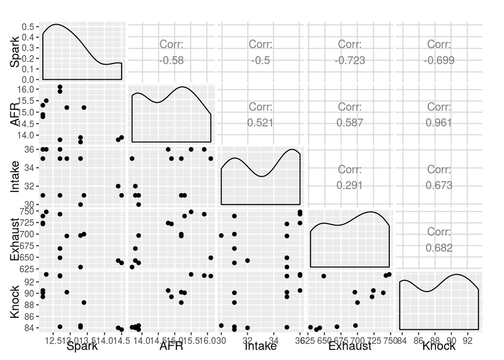

```r
ggpairs(data = knock)
```

```r
# Knock and Spark seem to be negatively correlated; Knock is positively correlated with each of other predictors.
```

2. Let us compute a multiple linear regression between `Knock` and the predictors (additive model).

```r
# Fit the linear model
fm1 <- lm(formula = Knock ~ Spark + AFR + Intake + Exhaust, data = knock)
summary(fm1)
```

```
##
## Call:
## lm(formula = Knock ~ Spark + AFR + Intake + Exhaust, data = knock)
##
## Residuals:
##     Min      1Q  Median      3Q     Max
## -0.5682 -0.4409  0.0625  0.3264  0.7399
##
## Coefficients:
##              Estimate Std. Error t value Pr(>|t|)
## (Intercept) 23.814922   8.136731   2.927  0.01909 *
## Spark       -0.296490   0.307181  -0.965  0.36271
## AFR          3.191814   0.239804  13.310  9.7e-07 ***
## Intake       0.358704   0.078482   4.571  0.00182 **
## Exhaust      0.013376   0.005421   2.467  0.03886 *
## ---
## Signif. codes:  0 '***' 0.001 '**' 0.01 '*' 0.05 '.' 0.1 ' ' 1
##
## Residual standard error: 0.5106 on 8 degrees of freedom
## Multiple R-squared:  0.9879, Adjusted R-squared:  0.9818
## F-statistic: 163.3 on 4 and 8 DF,  p-value: 1.062e-07
```

```r
# For example the variable Spark seems to be not significant, but if we exclude the variable Exhaust from the model, then Spark becomes significant. This fact is due to the high correlation between the two variables.
fm2 <- lm(formula = Knock ~ Spark + AFR + Intake, data = knock)
summary(fm2)
```

```
##
## Call:
## lm(formula = Knock ~ Spark + AFR + Intake, data = knock)
##
## Residuals:
##     Min      1Q  Median      3Q     Max
## -0.8632 -0.3445 -0.1213  0.3176  1.1365
##
## Coefficients:
##             Estimate Std. Error t value Pr(>|t|)
## (Intercept) 37.49747    7.45023   5.033 0.000706 ***
## Spark       -0.75996    0.30411  -2.499 0.033920 *
## AFR          3.40446    0.27999  12.159 6.88e-07 ***
## Intake       0.31234    0.09534   3.276 0.009587 **
## ---
## Signif. codes:  0 '***' 0.001 '**' 0.01 '*' 0.05 '.' 0.1 ' ' 1
##
## Residual standard error: 0.6388 on 9 degrees of freedom
## Multiple R-squared:  0.9787, Adjusted R-squared:  0.9716
## F-statistic: 137.8 on 3 and 9 DF,  p-value: 7.72e-08
```

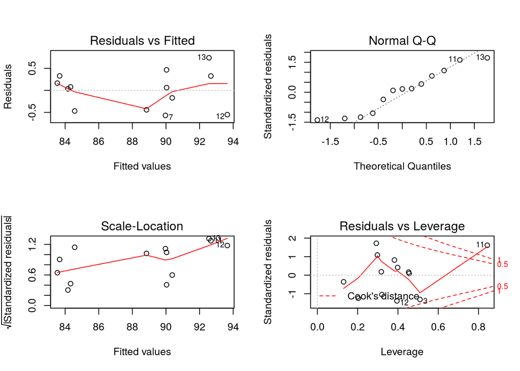

```r
# Overall the model explains the 98.79% of the variability of the response; also the value of the adjusted R^2 (98.18%) is very high.

# Residuals analysis
op <- par(mfrow = c(2,2))
plot(fm1)
```

```r
par(op)
```

3. Is It possible to improve the resulting model? How?

```r
# Improve the model: remove the variable Spark, which is not significant, from the model
fm3 <- update(fm1,.~. - Spark)
summary(fm3)
```

```
##
## Call:
## lm(formula = Knock ~ AFR + Intake + Exhaust, data = knock)
##
## Residuals:
##      Min       1Q   Median       3Q      Max
## -0.72826 -0.37966  0.08205  0.28129  0.67479
##
## Coefficients:
##              Estimate Std. Error t value Pr(>|t|)
## (Intercept) 16.487725   2.917508   5.651 0.000313 ***
## AFR          3.214814   0.237709  13.524 2.76e-07 ***
## Intake       0.386365   0.072784   5.308 0.000488 ***
## Exhaust      0.016576   0.004273   3.879 0.003737 **
## ---
## Signif. codes:  0 '***' 0.001 '**' 0.01 '*' 0.05 '.' 0.1 ' ' 1
##
## Residual standard error: 0.5086 on 9 degrees of freedom
## Multiple R-squared:  0.9865, Adjusted R-squared:  0.982
## F-statistic: 219.1 on 3 and 9 DF,  p-value: 9.962e-09
```

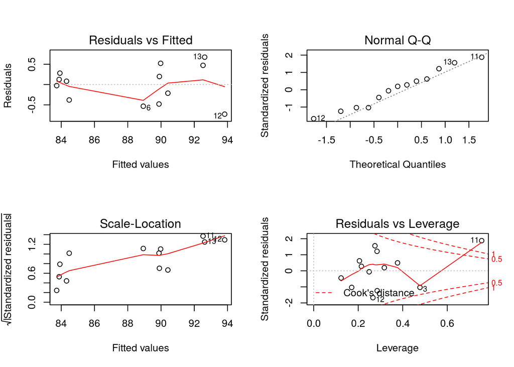

```r
# Residuals analysis
op <- par(mfrow = c(2,2))
plot(fm3)
```

```r
par(op)
```

4. Compare the initial with the final model.

```r
anova(fm1, fm3)
```

```
## Analysis of Variance Table
##
## Model 1: Knock ~ Spark + AFR + Intake + Exhaust
## Model 2: Knock ~ AFR + Intake + Exhaust
##   Res.Df    RSS Df Sum of Sq      F Pr(>F)
## 1      8 2.0854
## 2      9 2.3282 -1  -0.24284 0.9316 0.3627
```

```r
# There is a non-significant difference between the two models. fm3 seems the better model.
```

### Exercise 4

A researcher wants to determine which variables are related with the percentage of mortality. Data contains the following variables:

- `Rain`: indicates the annual average rainfall;
- `JanTemp`: indicates the average temperatures in January;
- `JulyTemp`: indicates the average temperatures in July;
- `PctOver65`: indicates the percentage of the population over 65 years;
- `HHSize`: indicates the average size of housing;
- `Education`: indicates the years of education;
- `PctHomesLiveable`: indicates the percentage of “habitable” homes;
- `PopDensity`: indicates the density of population;
- `PctLowIncome`: indicates the percentage of low-income families;
- `PctWhiteCollar`: indicates the percentage of employees;
- `Hydrocarbon`: indicates the pollution level by hydrocarbons;
- `NititeOxide`: indicates the pollution level of nitrite oxide;
- `SulphurDioxide`: indicates the pollution level of sulfur dioxide;
- `RelHum`: indicates the annual average relative humidity at 1 PM;
- `MortalityRate`: indicates the mortality rate for 100000 people.

```r
data(mortality)
head(mortality)
```

```
## Source: local data frame [6 x 15]
##
##    Rain JanTemp JulyTemp PctOver65 HHSize Education PctHomesLiveable
##   (int)   (int)    (int)     (dbl)  (dbl)     (dbl)            (dbl)
## 1    36      27       71       8.1   3.34      11.4             81.5
## 2    35      23       72      11.1   3.14      11.0             78.8
## 3    44      29       74      10.4   3.21       9.8             81.6
## 4    47      45       79       6.5   3.41      11.1             77.5
## 5    43      35       77       7.6   3.44       9.6             84.6
## 6    53      45       80       7.7   3.45      10.2             66.8
## Variables not shown: PopDensity (int), PctLowIncome (dbl), PctWhiteCollar
##   (dbl), Hydrocarbon (int), NititeOxide (int), SulphurDioxide (int),
##   RelHum (int), MortalityRate (dbl)
```

1. Let us build the complete model, with all the regressors (additive model).

```r
# Fit the linear model
fm1 <- lm(formula = MortalityRate ~ RelHum + SulphurDioxide + NititeOxide + Hydrocarbon + PctWhiteCollar + PctLowIncome + PopDensity + PctHomesLiveable + Education + HHSize + PctOver65 + JulyTemp + JanTemp + Rain, data = mortality)

summary(fm1)
```

```
##
## Call:
## lm(formula = MortalityRate ~ RelHum + SulphurDioxide + NititeOxide +
##     Hydrocarbon + PctWhiteCollar + PctLowIncome + PopDensity +
##     PctHomesLiveable + Education + HHSize + PctOver65 + JulyTemp +
##     JanTemp + Rain, data = mortality)
##
## Residuals:
##     Min      1Q  Median      3Q     Max
## -67.643 -17.969   0.836  19.098  87.012
##
## Coefficients:
##                    Estimate Std. Error t value Pr(>|t|)
## (Intercept)       1.760e+03  4.270e+02   4.122 0.000159 ***
## RelHum            1.174e-01  1.139e+00   0.103 0.918323
## SulphurDioxide    8.686e-02  1.454e-01   0.597 0.553222
## NititeOxide       1.338e+00  9.935e-01   1.347 0.184813
## Hydrocarbon      -6.702e-01  4.841e-01  -1.385 0.173024
## PctWhiteCollar   -1.704e-01  1.613e+00  -0.106 0.916322
## PctLowIncome      4.424e+00  1.126e+00   3.930 0.000290 ***
## PopDensity        3.625e-03  3.955e-03   0.917 0.364262
## PctHomesLiveable -5.965e-01  1.404e+00  -0.425 0.673079
## Education        -1.714e+01  1.172e+01  -1.462 0.150678
## HHSize           -1.072e+02  6.862e+01  -1.562 0.125213
## PctOver65        -9.218e+00  7.868e+00  -1.172 0.247501
## JulyTemp         -3.115e+00  1.860e+00  -1.674 0.101021
## JanTemp          -1.976e+00  8.172e-01  -2.418 0.019714 *
## Rain              1.916e+00  8.890e-01   2.156 0.036483 *
## ---
## Signif. codes:  0 '***' 0.001 '**' 0.01 '*' 0.05 '.' 0.1 ' ' 1
##
## Residual standard error: 34.54 on 45 degrees of freedom
## Multiple R-squared:  0.7649, Adjusted R-squared:  0.6917
## F-statistic: 10.46 on 14 and 45 DF,  p-value: 6.576e-10
```

2. Let us reach to a model in which all the regressors have significant terms at the 5% level, by eliminating a regressor at a time.

```r
# Remove RelHum
fm2 <- update(fm1,.~. -RelHum)
summary(fm2)
```

```
##
## Call:
## lm(formula = MortalityRate ~ SulphurDioxide + NititeOxide + Hydrocarbon +
##     PctWhiteCollar + PctLowIncome + PopDensity + PctHomesLiveable +
##     Education + HHSize + PctOver65 + JulyTemp + JanTemp + Rain,
##     data = mortality)
##
## Residuals:
##    Min     1Q Median     3Q    Max
## -67.82 -18.18   0.66  18.84  87.57
##
## Coefficients:
##                    Estimate Std. Error t value Pr(>|t|)
## (Intercept)       1.777e+03  3.931e+02   4.519 4.33e-05 ***
## SulphurDioxide    8.855e-02  1.429e-01   0.620 0.538541
## NititeOxide       1.325e+00  9.751e-01   1.359 0.180758
## Hydrocarbon      -6.677e-01  4.782e-01  -1.396 0.169358
## PctWhiteCollar   -1.892e-01  1.585e+00  -0.119 0.905476
## PctLowIncome      4.444e+00  1.097e+00   4.050 0.000195 ***
## PopDensity        3.595e-03  3.902e-03   0.921 0.361662
## PctHomesLiveable -6.046e-01  1.387e+00  -0.436 0.664918
## Education        -1.699e+01  1.150e+01  -1.477 0.146599
## HHSize           -1.078e+02  6.763e+01  -1.594 0.117756
## PctOver65        -9.200e+00  7.781e+00  -1.182 0.243140
## JulyTemp         -3.230e+00  1.468e+00  -2.200 0.032868 *
## JanTemp          -1.949e+00  7.674e-01  -2.540 0.014513 *
## Rain              1.918e+00  8.793e-01   2.181 0.034348 *
## ---
## Signif. codes:  0 '***' 0.001 '**' 0.01 '*' 0.05 '.' 0.1 ' ' 1
##
## Residual standard error: 34.17 on 46 degrees of freedom
## Multiple R-squared:  0.7648, Adjusted R-squared:  0.6983
## F-statistic: 11.51 on 13 and 46 DF,  p-value: 1.885e-10
```

```r
# Remove PctWhiteCollar
fm3 <- update(fm2,.~. -PctWhiteCollar)
summary(fm3)
```

```
##
## Call:
## lm(formula = MortalityRate ~ SulphurDioxide + NititeOxide + Hydrocarbon +
##     PctLowIncome + PopDensity + PctHomesLiveable + Education +
##     HHSize + PctOver65 + JulyTemp + JanTemp + Rain, data = mortality)
##
## Residuals:
##     Min      1Q  Median      3Q     Max
## -68.860 -18.251   0.714  18.832  86.834
##
## Coefficients:
##                    Estimate Std. Error t value Pr(>|t|)
## (Intercept)       1.775e+03  3.888e+02   4.566 3.59e-05 ***
## SulphurDioxide    8.414e-02  1.366e-01   0.616 0.540865
## NititeOxide       1.354e+00  9.353e-01   1.447 0.154412
## Hydrocarbon      -6.798e-01  4.624e-01  -1.470 0.148130
## PctLowIncome      4.421e+00  1.069e+00   4.136 0.000145 ***
## PopDensity        3.526e-03  3.818e-03   0.924 0.360459
## PctHomesLiveable -5.812e-01  1.359e+00  -0.428 0.670738
## Education        -1.783e+01  8.971e+00  -1.988 0.052663 .
## HHSize           -1.069e+02  6.649e+01  -1.608 0.114583
## PctOver65        -9.319e+00  7.635e+00  -1.220 0.228371
## JulyTemp         -3.249e+00  1.444e+00  -2.250 0.029192 *
## JanTemp          -1.962e+00  7.519e-01  -2.610 0.012117 *
## Rain              1.929e+00  8.646e-01   2.231 0.030462 *
## ---
## Signif. codes:  0 '***' 0.001 '**' 0.01 '*' 0.05 '.' 0.1 ' ' 1
##
## Residual standard error: 33.81 on 47 degrees of freedom
## Multiple R-squared:  0.7647, Adjusted R-squared:  0.7047
## F-statistic: 12.73 on 12 and 47 DF,  p-value: 5.138e-11
```

```r
# Remove PctHomesLiveable
fm4 <- update(fm3,.~. -PctHomesLiveable)
summary(fm4)
```

```
##
## Call:
## lm(formula = MortalityRate ~ SulphurDioxide + NititeOxide + Hydrocarbon +
##     PctLowIncome + PopDensity + Education + HHSize + PctOver65 +
##     JulyTemp + JanTemp + Rain, data = mortality)
##
## Residuals:
##     Min      1Q  Median      3Q     Max
## -69.845 -19.469   1.776  17.479  86.158
##
## Coefficients:
##                  Estimate Std. Error t value Pr(>|t|)
## (Intercept)     1.741e+03  3.773e+02   4.614 2.96e-05 ***
## SulphurDioxide  6.680e-02  1.293e-01   0.517   0.6079
## NititeOxide     1.428e+00  9.112e-01   1.568   0.1235
## Hydrocarbon    -7.200e-01  4.488e-01  -1.604   0.1152
## PctLowIncome    4.597e+00  9.778e-01   4.702 2.21e-05 ***
## PopDensity      3.051e-03  3.622e-03   0.842   0.4037
## Education      -1.961e+01  7.884e+00  -2.487   0.0164 *
## HHSize         -1.071e+02  6.592e+01  -1.624   0.1109
## PctOver65      -8.815e+00  7.480e+00  -1.179   0.2444
## JulyTemp       -3.162e+00  1.418e+00  -2.230   0.0304 *
## JanTemp        -2.000e+00  7.403e-01  -2.702   0.0095 **
## Rain            1.872e+00  8.470e-01   2.211   0.0319 *
## ---
## Signif. codes:  0 '***' 0.001 '**' 0.01 '*' 0.05 '.' 0.1 ' ' 1
##
## Residual standard error: 33.52 on 48 degrees of freedom
## Multiple R-squared:  0.7638, Adjusted R-squared:  0.7097
## F-statistic: 14.11 on 11 and 48 DF,  p-value: 1.438e-11
```

```r
# Remove SulphurDioxide
fm5 <- update(fm4,.~. -SulphurDioxide)
summary(fm5)
```

```
##
## Call:
## lm(formula = MortalityRate ~ NititeOxide + Hydrocarbon + PctLowIncome +
##     PopDensity + Education + HHSize + PctOver65 + JulyTemp +
##     JanTemp + Rain, data = mortality)
##
## Residuals:
##     Min      1Q  Median      3Q     Max
## -69.323 -17.906   2.037  17.181  82.642
##
## Coefficients:
##                Estimate Std. Error t value Pr(>|t|)
## (Intercept)   1.791e+03  3.620e+02   4.948 9.24e-06 ***
## NititeOxide   1.772e+00  6.171e-01   2.872  0.00601 **
## Hydrocarbon  -8.803e-01  3.218e-01  -2.736  0.00864 **
## PctLowIncome  4.616e+00  9.697e-01   4.760 1.75e-05 ***
## PopDensity    3.525e-03  3.478e-03   1.014  0.31580
## Education    -2.061e+01  7.585e+00  -2.717  0.00908 **
## HHSize       -1.138e+02  6.414e+01  -1.774  0.08235 .
## PctOver65    -9.654e+00  7.246e+00  -1.332  0.18896
## JulyTemp     -3.239e+00  1.399e+00  -2.315  0.02483 *
## JanTemp      -2.081e+00  7.180e-01  -2.899  0.00559 **
## Rain          1.834e+00  8.374e-01   2.190  0.03331 *
## ---
## Signif. codes:  0 '***' 0.001 '**' 0.01 '*' 0.05 '.' 0.1 ' ' 1
##
## Residual standard error: 33.27 on 49 degrees of freedom
## Multiple R-squared:  0.7625, Adjusted R-squared:  0.714
## F-statistic: 15.73 on 10 and 49 DF,  p-value: 3.959e-12
```

```r
# Remove PopDensity
fm6 <- update(fm5,.~. -PopDensity)
summary(fm6)
```

```
##
## Call:
## lm(formula = MortalityRate ~ NititeOxide + Hydrocarbon + PctLowIncome +
##     Education + HHSize + PctOver65 + JulyTemp + JanTemp + Rain,
##     data = mortality)
##
## Residuals:
##     Min      1Q  Median      3Q     Max
## -71.086 -22.005   0.677  16.884  79.771
##
## Coefficients:
##               Estimate Std. Error t value Pr(>|t|)
## (Intercept)  1934.0520   333.4975   5.799 4.48e-07 ***
## NititeOxide     1.8711     0.6095   3.070  0.00346 **
## Hydrocarbon    -0.9221     0.3192  -2.889  0.00571 **
## PctLowIncome    4.6623     0.9689   4.812 1.42e-05 ***
## Education     -23.4211     7.0620  -3.317  0.00170 **
## HHSize       -137.3853    59.7749  -2.298  0.02576 *
## PctOver65     -10.9203     7.1398  -1.529  0.13244
## JulyTemp       -3.3199     1.3971  -2.376  0.02136 *
## JanTemp        -2.2620     0.6957  -3.252  0.00206 **
## Rain            1.8565     0.8373   2.217  0.03119 *
## ---
## Signif. codes:  0 '***' 0.001 '**' 0.01 '*' 0.05 '.' 0.1 ' ' 1
##
## Residual standard error: 33.27 on 50 degrees of freedom
## Multiple R-squared:  0.7575, Adjusted R-squared:  0.7139
## F-statistic: 17.36 on 9 and 50 DF,  p-value: 1.481e-12
```

```r
# Remove PctOver65
fm7 <- update(fm6,.~. -PctOver65)
summary(fm7)
```

```
##
## Call:
## lm(formula = MortalityRate ~ NititeOxide + Hydrocarbon + PctLowIncome +
##     Education + HHSize + JulyTemp + JanTemp + Rain, data = mortality)
##
## Residuals:
##    Min     1Q Median     3Q    Max
## -74.46 -21.79   2.49  14.20  78.80
##
## Coefficients:
##               Estimate Std. Error t value Pr(>|t|)
## (Intercept)  1550.1868   222.4841   6.968 6.12e-09 ***
## NititeOxide     1.7050     0.6076   2.806  0.00708 **
## Hydrocarbon    -0.8596     0.3207  -2.680  0.00989 **
## PctLowIncome    5.4513     0.8309   6.561 2.69e-08 ***
## Education     -19.3424     6.6244  -2.920  0.00520 **
## HHSize        -77.3749    45.6841  -1.694  0.09642 .
## JulyTemp       -2.6025     1.3332  -1.952  0.05643 .
## JanTemp        -1.8236     0.6421  -2.840  0.00647 **
## Rain            1.0757     0.6724   1.600  0.11581
## ---
## Signif. codes:  0 '***' 0.001 '**' 0.01 '*' 0.05 '.' 0.1 ' ' 1
##
## Residual standard error: 33.71 on 51 degrees of freedom
## Multiple R-squared:  0.7462, Adjusted R-squared:  0.7064
## F-statistic: 18.74 on 8 and 51 DF,  p-value: 9.77e-13
```

```r
# Remove Rain
fm8 <- update(fm7,.~. -Rain)
summary(fm8)
```

```
##
## Call:
## lm(formula = MortalityRate ~ NititeOxide + Hydrocarbon + PctLowIncome +
##     Education + HHSize + JulyTemp + JanTemp, data = mortality)
##
## Residuals:
##     Min      1Q  Median      3Q     Max
## -70.598 -16.127  -2.014  15.473  81.067
##
## Coefficients:
##               Estimate Std. Error t value Pr(>|t|)
## (Intercept)  1671.9562   212.1716   7.880 1.97e-10 ***
## NititeOxide     1.7733     0.6151   2.883 0.005717 **
## Hydrocarbon    -0.9544     0.3199  -2.984 0.004332 **
## PctLowIncome    5.8255     0.8092   7.199 2.38e-09 ***
## Education     -23.6132     6.1530  -3.838 0.000338 ***
## HHSize        -93.5086    45.2204  -2.068 0.043647 *
## JulyTemp       -2.4493     1.3495  -1.815 0.075308 .
## JanTemp        -1.7027     0.6472  -2.631 0.011177 *
## ---
## Signif. codes:  0 '***' 0.001 '**' 0.01 '*' 0.05 '.' 0.1 ' ' 1
##
## Residual standard error: 34.21 on 52 degrees of freedom
## Multiple R-squared:  0.7334, Adjusted R-squared:  0.6976
## F-statistic: 20.44 on 7 and 52 DF,  p-value: 6.836e-13
```

```r
# Remove JulyTemp
fm9 <- update(fm8,.~. -JulyTemp)
summary(fm9)
```

```
##
## Call:
## lm(formula = MortalityRate ~ NititeOxide + Hydrocarbon + PctLowIncome +
##     Education + HHSize + JanTemp, data = mortality)
##
## Residuals:
##     Min      1Q  Median      3Q     Max
## -72.476 -16.074   2.035  20.478  85.068
##
## Coefficients:
##               Estimate Std. Error t value Pr(>|t|)
## (Intercept)  1474.1751   185.9446   7.928 1.46e-10 ***
## NititeOxide     1.7915     0.6282   2.852 0.006185 **
## Hydrocarbon    -0.9061     0.3256  -2.783 0.007454 **
## PctLowIncome    5.2463     0.7595   6.907 6.35e-09 ***
## Education     -22.4846     6.2525  -3.596 0.000709 ***
## HHSize        -87.6989    46.0727  -1.903 0.062413 .
## JanTemp        -2.0441     0.6325  -3.232 0.002117 **
## ---
## Signif. codes:  0 '***' 0.001 '**' 0.01 '*' 0.05 '.' 0.1 ' ' 1
##
## Residual standard error: 34.94 on 53 degrees of freedom
## Multiple R-squared:  0.7166, Adjusted R-squared:  0.6845
## F-statistic: 22.33 on 6 and 53 DF,  p-value: 6.402e-13
```

```r
# Remove HHSize
fm10 <- update(fm9,.~. -HHSize)
summary(fm10)
```

```
##
## Call:
## lm(formula = MortalityRate ~ NititeOxide + Hydrocarbon + PctLowIncome +
##     Education + JanTemp, data = mortality)
##
## Residuals:
##     Min      1Q  Median      3Q     Max
## -83.179 -16.126  -1.545  21.053  85.979
##
## Coefficients:
##               Estimate Std. Error t value Pr(>|t|)
## (Intercept)  1145.1944    70.2397  16.304  < 2e-16 ***
## NititeOxide     1.9924     0.6341   3.142  0.00272 **
## Hydrocarbon    -0.9844     0.3308  -2.976  0.00436 **
## PctLowIncome    4.4613     0.6531   6.831 7.75e-09 ***
## Education     -19.3693     6.1794  -3.135  0.00278 **
## JanTemp        -1.5629     0.5937  -2.633  0.01103 *
## ---
## Signif. codes:  0 '***' 0.001 '**' 0.01 '*' 0.05 '.' 0.1 ' ' 1
##
## Residual standard error: 35.78 on 54 degrees of freedom
## Multiple R-squared:  0.6972, Adjusted R-squared:  0.6691
## F-statistic: 24.87 on 5 and 54 DF,  p-value: 6.603e-13
```

```r
# Using other criterions to determine the significant variables, the resulting model could be different.
fm11 <- stepAIC(object = fm1)
```

```
## Start:  AIC=437.79
## MortalityRate ~ RelHum + SulphurDioxide + NititeOxide + Hydrocarbon +
##     PctWhiteCollar + PctLowIncome + PopDensity + PctHomesLiveable +
##     Education + HHSize + PctOver65 + JulyTemp + JanTemp + Rain
##
##                    Df Sum of Sq   RSS    AIC
## - RelHum            1      12.7 53696 435.81
## - PctWhiteCollar    1      13.3 53697 435.81
## - PctHomesLiveable  1     215.2 53899 436.03
## - SulphurDioxide    1     425.8 54110 436.27
## - PopDensity        1    1002.2 54686 436.90
## - PctOver65         1    1637.7 55321 437.59
## <none>                          53684 437.79
## - NititeOxide       1    2163.7 55847 438.16
## - Hydrocarbon       1    2286.8 55971 438.29
## - Education         1    2550.1 56234 438.58
## - HHSize            1    2912.0 56596 438.96
## - JulyTemp          1    3344.0 57028 439.42
## - Rain              1    5544.4 59228 441.69
## - JanTemp           1    6975.3 60659 443.12
## - PctLowIncome      1   18423.3 72107 453.49
##
## Step:  AIC=435.81
## MortalityRate ~ SulphurDioxide + NititeOxide + Hydrocarbon +
##     PctWhiteCollar + PctLowIncome + PopDensity + PctHomesLiveable +
##     Education + HHSize + PctOver65 + JulyTemp + JanTemp + Rain
##
##                    Df Sum of Sq   RSS    AIC
## - PctWhiteCollar    1      16.6 53713 433.82
## - PctHomesLiveable  1     221.8 53918 434.05
## - SulphurDioxide    1     448.2 54145 434.30
## - PopDensity        1     991.0 54687 434.90
## - PctOver65         1    1631.9 55328 435.60
## <none>                          53696 435.81
## - NititeOxide       1    2156.0 55853 436.17
## - Hydrocarbon       1    2275.5 55972 436.30
## - Education         1    2545.1 56242 436.58
## - HHSize            1    2966.4 56663 437.03
## - Rain              1    5551.7 59248 439.71
## - JulyTemp          1    5649.9 59346 439.81
```

[output cut: 59 more lines]

```
## Step:  AIC=429.63
## MortalityRate ~ NititeOxide + Hydrocarbon + PctLowIncome + Education +
##     HHSize + PctOver65 + JulyTemp + JanTemp + Rain
##
##                Df Sum of Sq   RSS    AIC
## <none>                      55359 429.63
## - PctOver65     1    2590.1 57949 430.38
## - Rain          1    5442.6 60801 433.26
## - HHSize        1    5848.7 61207 433.66
## - JulyTemp      1    6251.9 61611 434.05
## - Hydrocarbon   1    9238.3 64597 436.89
## - NititeOxide   1   10433.6 65792 437.99
## - JanTemp       1   11706.0 67065 439.14
## - Education     1   12178.1 67537 439.57
## - PctLowIncome  1   25634.2 80993 450.47
```

```r
summary(fm11)
```

```
##
## Call:
## lm(formula = MortalityRate ~ NititeOxide + Hydrocarbon + PctLowIncome +
##     Education + HHSize + PctOver65 + JulyTemp + JanTemp + Rain,
##     data = mortality)
##
## Residuals:
##     Min      1Q  Median      3Q     Max
## -71.086 -22.005   0.677  16.884  79.771
##
## Coefficients:
##               Estimate Std. Error t value Pr(>|t|)
## (Intercept)  1934.0520   333.4975   5.799 4.48e-07 ***
## NititeOxide     1.8711     0.6095   3.070  0.00346 **
## Hydrocarbon    -0.9221     0.3192  -2.889  0.00571 **
## PctLowIncome    4.6623     0.9689   4.812 1.42e-05 ***
## Education     -23.4211     7.0620  -3.317  0.00170 **
## HHSize       -137.3853    59.7749  -2.298  0.02576 *
## PctOver65     -10.9203     7.1398  -1.529  0.13244
## JulyTemp       -3.3199     1.3971  -2.376  0.02136 *
## JanTemp        -2.2620     0.6957  -3.252  0.00206 **
## Rain            1.8565     0.8373   2.217  0.03119 *
## ---
## Signif. codes:  0 '***' 0.001 '**' 0.01 '*' 0.05 '.' 0.1 ' ' 1
##
## Residual standard error: 33.27 on 50 degrees of freedom
## Multiple R-squared:  0.7575, Adjusted R-squared:  0.7139
## F-statistic: 17.36 on 9 and 50 DF,  p-value: 1.481e-12
```

3. Let us check the residuals of the final model.

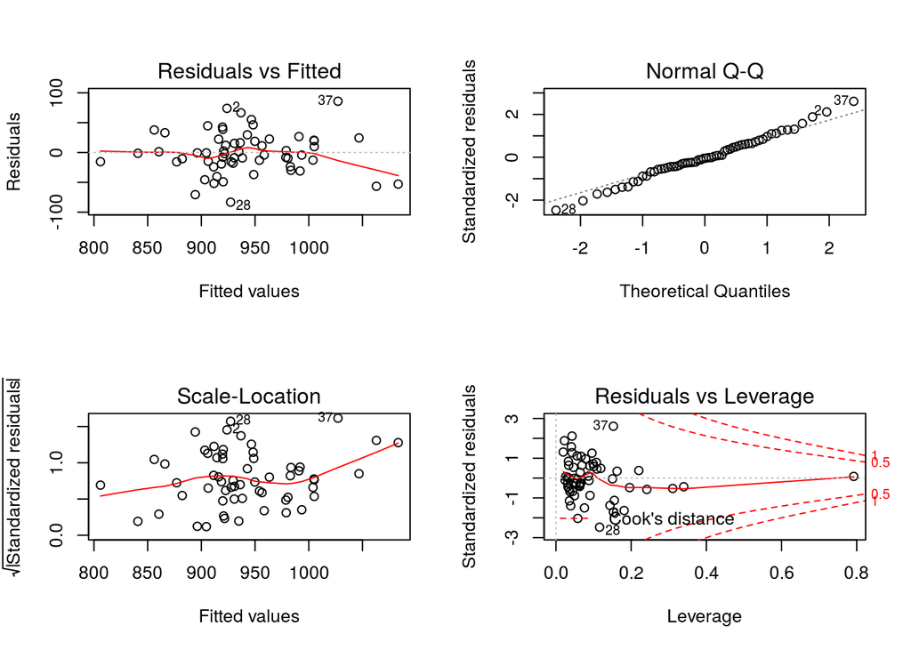

```r
# Residual Analysis of the final model
op <- par(mfrow = c(2,2))
plot(fm10)
```

```r
par(op)
```

4. Let us compare the initial and the final model.

```r
# Models Comparison
anova(fm1, fm11)
```

```
## Analysis of Variance Table
##
## Model 1: MortalityRate ~ RelHum + SulphurDioxide + NititeOxide + Hydrocarbon +
##     PctWhiteCollar + PctLowIncome + PopDensity + PctHomesLiveable +
##     Education + HHSize + PctOver65 + JulyTemp + JanTemp + Rain
## Model 2: MortalityRate ~ NititeOxide + Hydrocarbon + PctLowIncome + Education +
##     HHSize + PctOver65 + JulyTemp + JanTemp + Rain
##   Res.Df   RSS Df Sum of Sq      F Pr(>F)
## 1     45 53684
## 2     50 55359 -5   -1674.9 0.2808 0.9212
```

### Exercise 5

A researcher wants to establish if there is a relation between the weight of the body and the weight of the brain of fifteen mammal (african elephant, cow, monkey, man, gray wolf, red fox, armadillo, chinchilla and so on).

```r
data(brainbod)
head(brainbod)
```

```
## Source: local data frame [6 x 3]
##
##    Species    Body  Brain
##     (fctr)   (dbl)  (dbl)
## 1  afeleph 6654.00 5712.0
## 2      cow  465.00  423.0
## 3   donkey  187.00  419.0
## 4      man   62.00 1320.0
## 5 graywolf   36.33  119.5
## 6   redfox    4.24   50.4
```

1. Let us show the descriptive graphics (histogram and BW plot) of the `Body` and `Brain` variables.

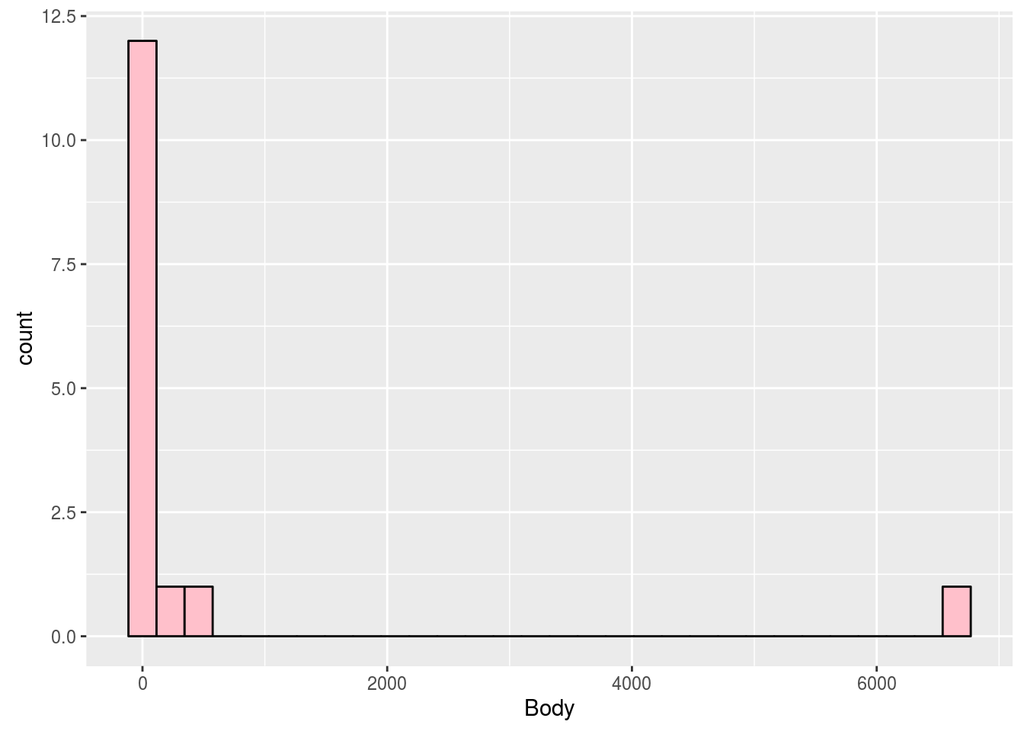

```r
# Body
pl1 <- ggplot(data = brainbod, mapping = aes(x=Body)) +
  geom_histogram(fill="pink", col="black")
print(pl1)
```

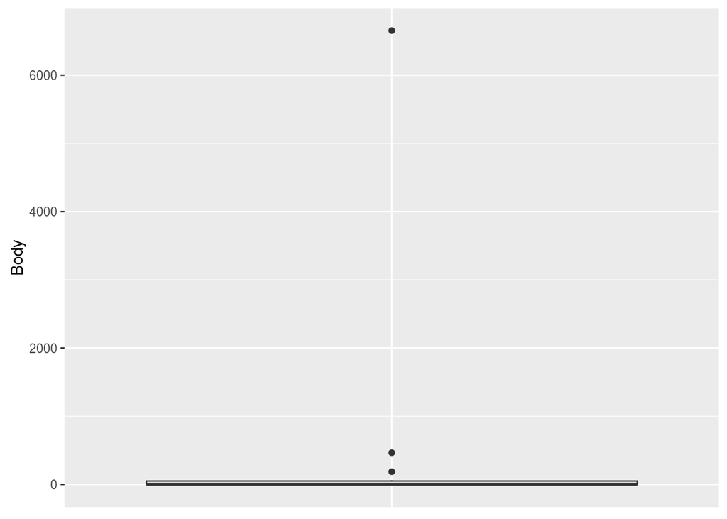

```r
pl2 <- ggplot(data = brainbod, mapping = aes(y=Body, x="0")) +
  geom_boxplot() + theme(axis.text.x=element_blank(), axis.title.x = element_blank(),
    axis.ticks.x=element_blank())
print(pl2)
```

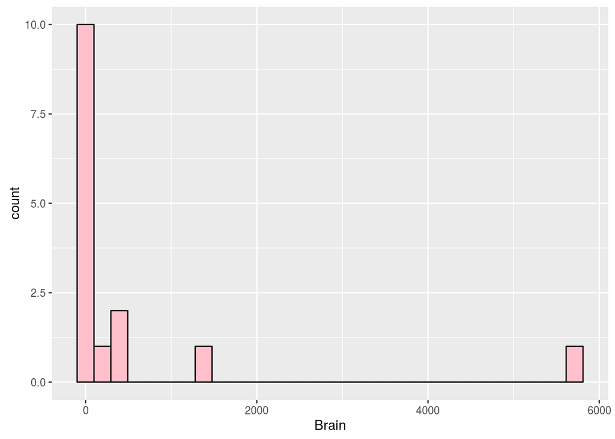

```r
# Brain
pl1 <- ggplot(data = brainbod, mapping = aes(x=Brain)) +
  geom_histogram(fill="pink", col="black")
print(pl1)
```

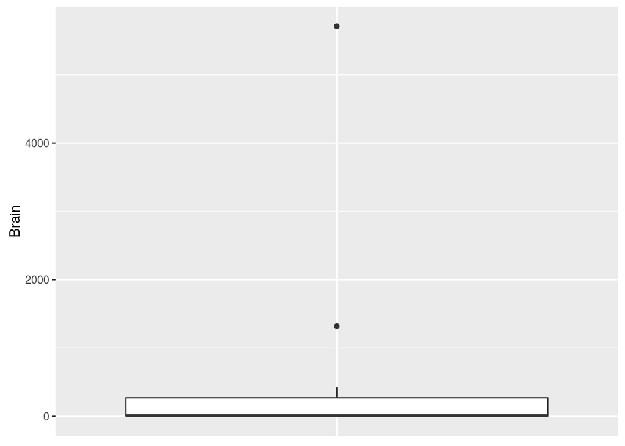

```r
pl2 <- ggplot(data = brainbod, mapping = aes(y=Brain, x="0")) +
  geom_boxplot() + theme(axis.text.x=element_blank(), axis.title.x = element_blank(),
    axis.ticks.x=element_blank())
print(pl2)
```

2. Let us show a scatterplot of the two variables. Let us estimate a linear regression model and check the model residuals. The linear model between the two variables is adequate? Why?

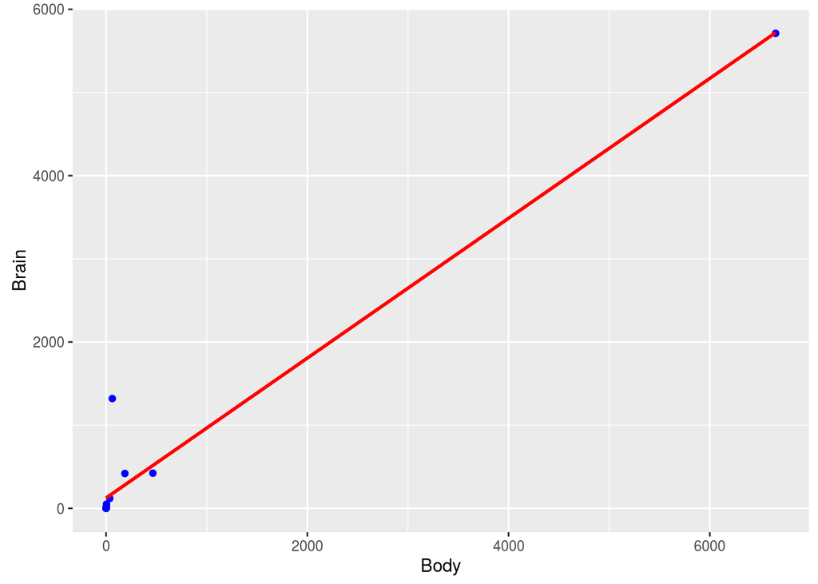

```r
# Scatterplot
pl3 <- ggplot(data = brainbod, mapping = aes(y=Brain, x=Body)) +
  geom_point(col="blue") + geom_smooth(method = "lm", colour= "red", se=FALSE)

print(pl3)
```

```r
# Fit the linear model
fm1 <- lm(formula = Brain ~ Body, data = brainbod)
summary(fm1)
```

```
##
## Call:
## lm(formula = Brain ~ Body, data = brainbod)
##
## Residuals:
##     Min      1Q  Median      3Q     Max
## -124.28 -121.29 -114.49  -56.63 1143.34
##
## Coefficients:
##              Estimate Std. Error t value Pr(>|t|)
## (Intercept) 124.52517   90.60557   1.374    0.193
## Body          0.84086    0.05259  15.990 6.26e-10 ***
## ---
## Signif. codes:  0 '***' 0.001 '**' 0.01 '*' 0.05 '.' 0.1 ' ' 1
##
## Residual standard error: 336.1 on 13 degrees of freedom
## Multiple R-squared:  0.9516, Adjusted R-squared:  0.9479
## F-statistic: 255.7 on 1 and 13 DF,  p-value: 6.257e-10
```

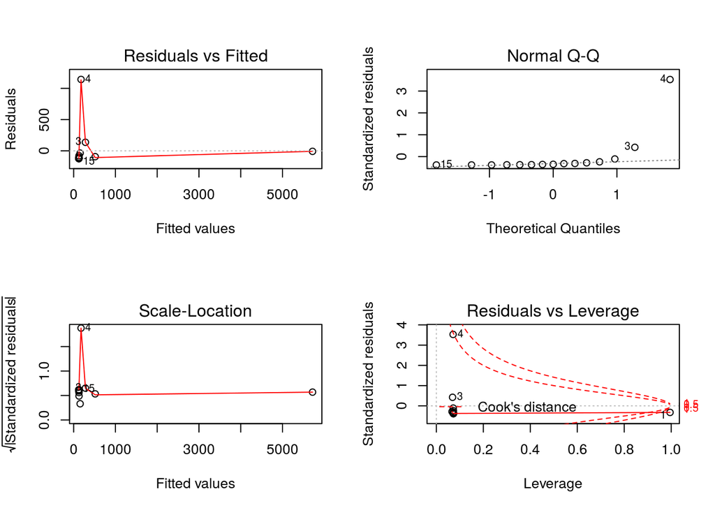

```r
# A linear regression seems to exist between the two variables. An high value of the R^2 (95.16%) implies that the link between body weight and brain weight is well explained by a linear regression.

# Residuals analysis
op <- par(mfrow = c(2,2))
plot(fm1)
```

```r
par(op)

# However, the weight of the African elephant is much higher than that of other animals, and It makes the graph and the regression curve illegible. A logarithmic transformation of the two variables may suggest a more clear reading of the graph and It may show understandably the relation between the two variables.
# The hypothesis of residual normality seems not to be accepted.
```

3. How could the model be improved? What variable transformation can be applied? Generate BW plot, histogram and scatterplot of the transformed variables.

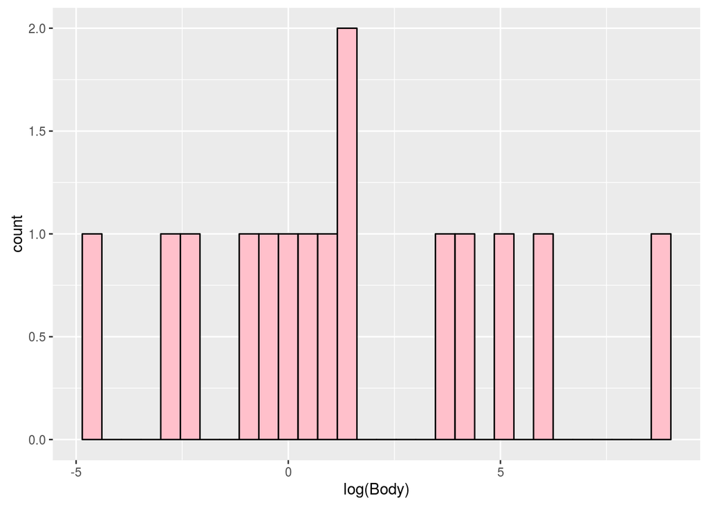

```r
# Body
pl1 <- ggplot(data = brainbod, mapping = aes(x=log(Body))) +
  geom_histogram(fill="pink", col="black")
print(pl1)
```

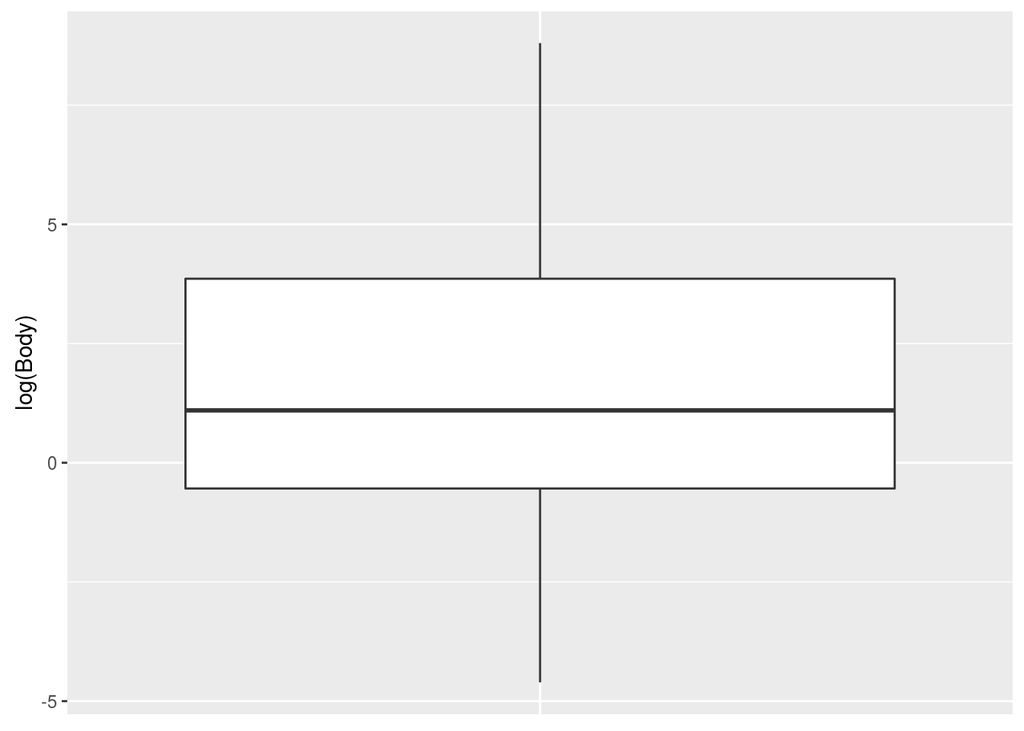

```r
pl2 <- ggplot(data = brainbod, mapping = aes(y=log(Body), x="0")) +
  geom_boxplot() + theme(axis.text.x=element_blank(), axis.title.x = element_blank(),
    axis.ticks.x=element_blank())
print(pl2)
```

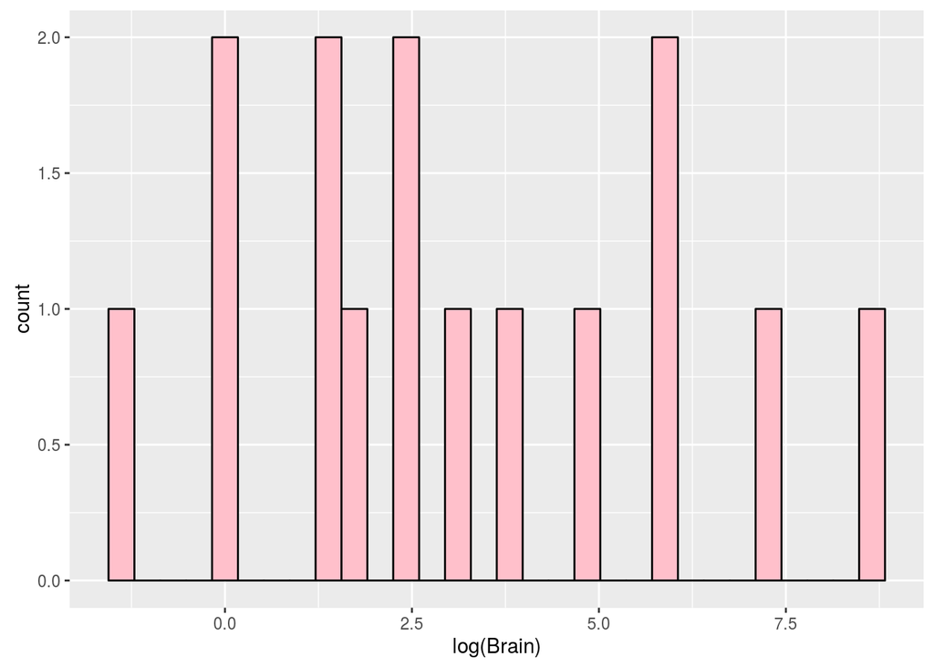

```r
# Brain
pl1 <- ggplot(data = brainbod, mapping = aes(x=log(Brain))) +
  geom_histogram(fill="pink", col="black")
print(pl1)
```